# Analysis of alcohol consumption data (Week 3)

## Loading data

I start by loading the alcohol consumption data set with the `read_csv` function from the `readr` library and print the name of its variables:

```r
# load the readr library
library(readr)

# load the data file
alc <- read_csv("data/alc.csv")
# print the variable names
colnames(alc)
```

```
##  [1] "school"     "sex"        "age"        "address"    "famsize"
##  [6] "Pstatus"    "Medu"       "Fedu"       "Mjob"       "Fjob"
## [11] "reason"     "guardian"   "traveltime" "studytime"  "schoolsup"
## [16] "famsup"     "activities" "nursery"    "higher"     "internet"
## [21] "romantic"   "famrel"     "freetime"   "goout"      "Dalc"
## [26] "Walc"       "health"     "failures"   "paid"       "absences"
## [31] "G1"         "G2"         "G3"         "alc_use"    "high_use"
```

The data of 370 observations is combined from two data sets describing student achievement in secondary education of two Portuguese schools (https://archive.ics.uci.edu/dataset/320/student+performance). The data attributes include student grades, demographic, social and school related features and it was collected by using school reports and questionnaires. This analysis studies students’ alcohol consumption, which is described by four variables in the data:

- `Dalc`: Workday alcohol consumption (numeric: from 1 - very low to 5 - very high)
- `Walc`: Weekend alcohol consumption (numeric: from 1 - very low to 5 - very high)
- `alc_use`: Average of `Dalc` and `Walc`
- `high_use`: `TRUE` if `alc_use > 2` and `FALSE` otherwise

In this report, I will mostly focus on the last variable and its relationship with some of the other variables in the data set.

## Four variables vs. alcohol consumption

Next, I will choose four interesting variables and hypothesize about their relationship with high/low alcohol consumption. The variables and hypotheses are:

- `activities`: Extra-curricular activities (binary: `yes` or `no`). My guess is that students with extra-curricular activities have less time to consume alcohol.
- `freetime`: Free time after school (numeric: from `1` - very low to `5` - very high). My prediction is that the amount of free time a student has correlates with the alcohol consumption.
- `famrel`: Quality of family relationships (numeric: from `1` - very bad to `5` - excellent). I hypothesize that this variable has an anti-correlation with alcohol use: a high quality of family relationship promotes less drinking and vice versa.
- `studytime`: Weekly study time (numeric: `1` - <2 hours, `2` - 2 to 5 hours, `3` - 5 to 10 hours, or `4` - >10 hours). For this one, I also assume an anti-correlation: students who study more are less likely to have time and/or motivation to go out and drink.

Let’s study numerically and graphically the distributions of the chosen variables and see if the hypotheses hold. First, it is useful to check the distributions of each variable of interest:

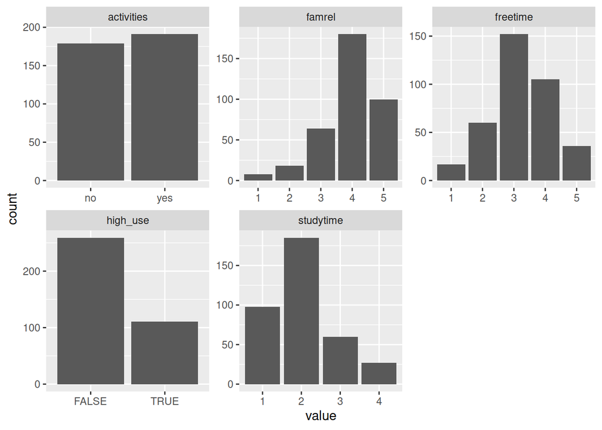

```r
# access the tidyverse libraries tidyr, dplyr, ggplot2
library(tidyr); library(dplyr); library(ggplot2)
# draw a bar plot of each variable
select(alc, all_of(c("high_use","activities","freetime","famrel","studytime"))) %>% gather %>% ggplot(aes(value)) + facet_wrap("key", scales = "free") + geom_bar()
```

It seems like almost third of the students are high users of alcohol. About half of them have extra-curricular activities, most of them have good family relations, and most study 2-5 hours a week. The `freetime` variable is not defined quantitatively, but most of the students consider to have intermediate amount of free time after school.

Next, some cross tabulations might reveal some relationships between the variables,

```r
# Cross tabulation of high alcohol use and activities
table(alc$high_use, alc$activities)
```

```
##
##          no yes
##   FALSE 120 139
##   TRUE   59  52
```

```r
# Cross tabulation of high alcohol use and free time
table(alc$high_use, alc$freetime)
```

```
##
##           1   2   3   4   5
##   FALSE  15  46 112  65  21
##   TRUE    2  14  40  40  15
```

```r
# Cross tabulation of high alcohol use and family relations
table(alc$high_use, alc$famrel)
```

```
##
##           1   2   3   4   5
##   FALSE   6   9  39 128  77
##   TRUE    2   9  25  52  23
```

```r
# Cross tabulation of high alcohol use and study time
table(alc$high_use, alc$studytime)
```

```
##
##           1   2   3   4
##   FALSE  56 128  52  23
##   TRUE   42  57   8   4
```

The same information presented graphically is perhaps easier to analyze,

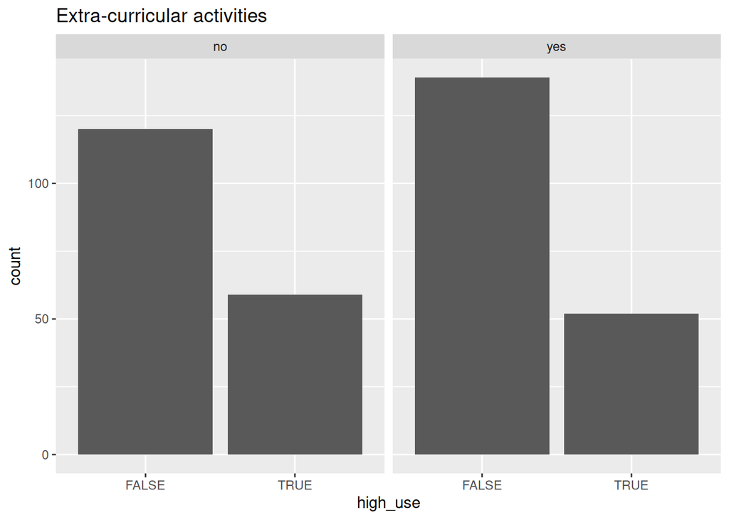

```r
# Plot high_use vs. activities
ggplot(data = alc, aes(x = high_use)) + geom_bar() + facet_wrap("activities") + ggtitle("Extra-curricular activities")
```

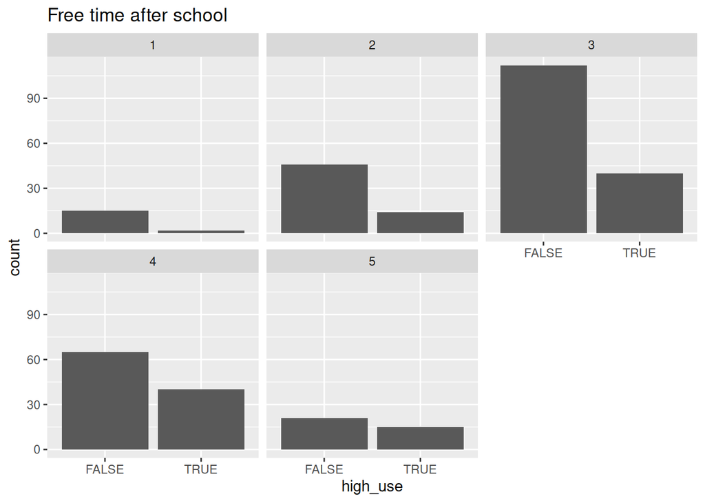

```r
# Plot high_use vs. freetime
ggplot(data = alc, aes(x = high_use)) + geom_bar() + facet_wrap("freetime") + ggtitle("Free time after school")
```

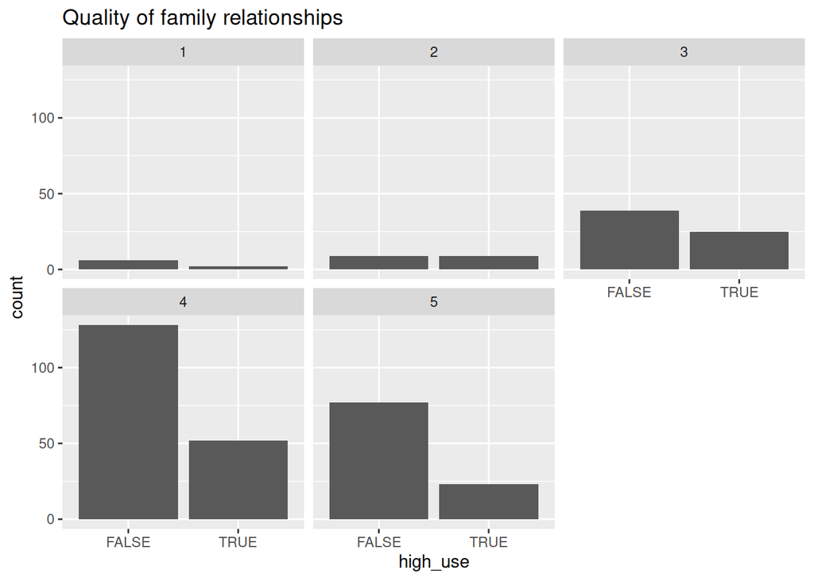

```r
# Plot high_use vs. famrel
ggplot(data = alc, aes(x = high_use)) + geom_bar() + facet_wrap("famrel") + ggtitle("Quality of family relationships")
```

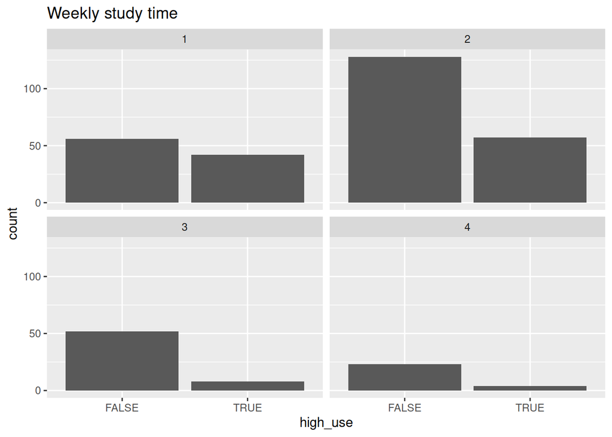

```r
# Plot high_use vs. studytime
ggplot(data = alc, aes(x = high_use)) + geom_bar() + facet_wrap("studytime") + ggtitle("Weekly study time")
```

In all of the four cases, the data seems to support my hypotheses at least by visually inspecting the distributions. Let’s approach the analysis more systematically and try to further solidify the hypotheses by using logistic regression to find statistically significant relationships between alcohol consumption (target variable) and the four chosen variables (predictors). Fitting a logistic regression model to the data yields

```r
# find the model with glm()
m <- glm(high_use ~ activities + freetime + famrel + studytime, data = alc, family = "binomial")

# print out a summary of the model
summary(m)
```

```
##
## Call:
## glm(formula = high_use ~ activities + freetime + famrel + studytime,
##     family = "binomial", data = alc)
##
## Coefficients:
##               Estimate Std. Error z value Pr(>|z|)
## (Intercept)     0.3793     0.6853   0.554 0.579899
## activitiesyes  -0.2363     0.2404  -0.983 0.325681
## freetime        0.3855     0.1267   3.042 0.002351 **
## famrel         -0.3365     0.1302  -2.584 0.009753 **
## studytime      -0.5460     0.1564  -3.491 0.000481 ***
## ---
## Signif. codes:  0 '***' 0.001 '**' 0.01 '*' 0.05 '.' 0.1 ' ' 1
##
## (Dispersion parameter for binomial family taken to be 1)
##
##     Null deviance: 452.04  on 369  degrees of freedom
## Residual deviance: 418.92  on 365  degrees of freedom
## AIC: 428.92
##
## Number of Fisher Scoring iterations: 4
```

From the coefficients of the model, describing the logarithms of odds ratios, I can already observe the hypothesized (anti-)correlation pattern. In the case of `activities` (with reference class `no`), the error of the estimate is, however, very large resulting in insignificant relationship with high alcohol use. For the other three variables, the relationship is much stronger, especially with `studytime`. The P-values of the fitted model tell the same story. Let’s study the coefficients in a bit more detail by computing the odds ratios (OR) and their 95% confidence intervals (CI). The former is obtained simply by exponentiating the above coefficients and the latter is given by the `confint` function,

```r
# compute odds ratios (OR)
OR <- coef(m) %>% exp

# compute confidence intervals (CI)
CI <- confint(m) %>% exp
# print out the odds ratios with their confidence intervals
cbind(OR, CI)
```

```
##                      OR     2.5 %    97.5 %
## (Intercept)   1.4612807 0.3790614 5.6153890
## activitiesyes 0.7895289 0.4919076 1.2645821
## freetime      1.4703933 1.1513380 1.8944541
## famrel        0.7142510 0.5521613 0.9215397
## studytime     0.5792716 0.4222494 0.7807407
```

The odds ratios and their confidence intervals have a clear interpretation. For `activities`, the odds ratio for having high alcohol use when having extra-curricular activities (vs. not having activities) is 0.79 with a 95% CI of [0.49,1.26]. As this interval contains the value 1 (1 means equal odds for `high_use` in both values of `activities`), I can conclude that there is no evidence of an association between `activities` and `high_use`. For `freetime`, the interpretation is that when `freetime` is increased by 1 unit, the odds ratio for `high_use` becomes 1.47 with CI of [1.15, 1.89]. In this case, the interval does not contain 1 so we can safely say that there is a statistically meaningful correlation between `freetime` and `high_use`. The same conclusion can be drawn for `famrel` and `studytime`, where I observe significant anticorrelation. As already hinted by the coefficients of the model, the conclusion is that `activities` is an irrelevant variable when considering `high_use` and the three other variables have a significant impact on `high_use`.

## Testing predictions

Using the three statistically significant variables `freetime`, `famrel`, and `studytime` for the target variable `high_use`, I can explore the predictive power of the model. Computing the probability of `high_use` given the three variables and obtaining the resulting predictions (>0.5 = `TRUE`) yields a cross tabulation

```r
# fit the model
m2 <- glm(high_use ~ freetime + famrel + studytime, data = alc, family = "binomial")

# predict() the probability of high_use
probabilities <- predict(m2, type = "response")

# add the predicted probabilities to 'alc'
alc <- mutate(alc, probability = probabilities)

# use the probabilities to make a prediction of high_use
alc <- mutate(alc, prediction = probability > 0.5)

# tabulate the target variable versus the predictions
table(Actual = alc$high_use, Predicted = alc$prediction) %>% prop.table() %>% addmargins()
```

```
##        Predicted
## Actual       FALSE       TRUE        Sum
##   FALSE 0.65675676 0.04324324 0.70000000
##   TRUE  0.26756757 0.03243243 0.30000000
##   Sum   0.92432432 0.07567568 1.00000000
```

which can be plotted

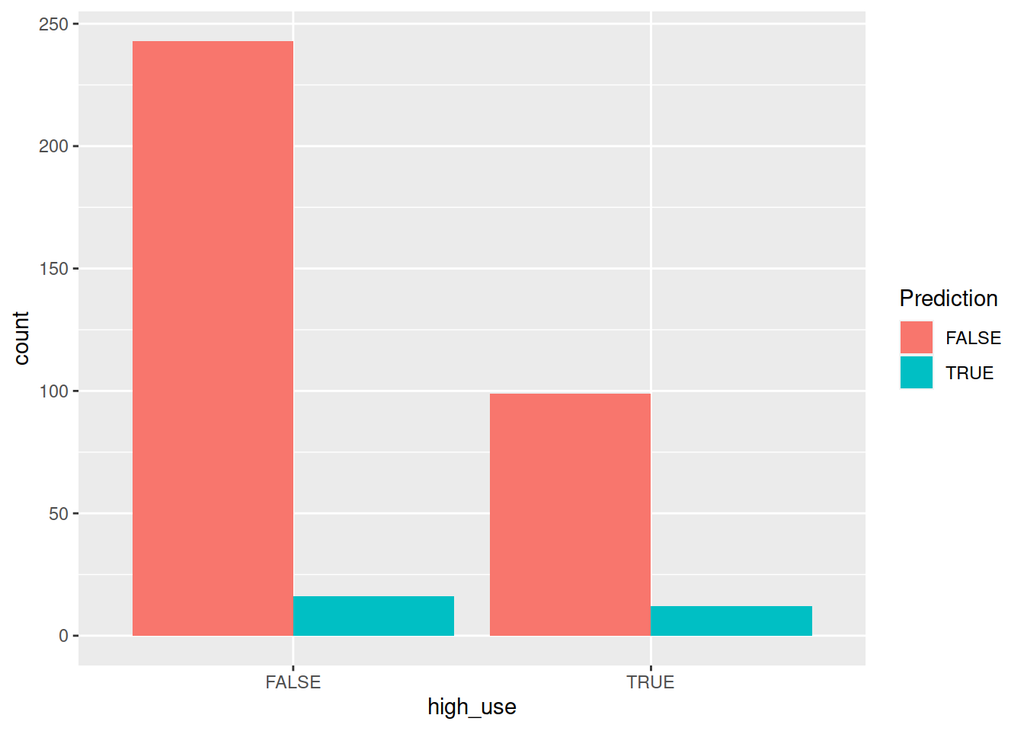

```r
# plot of the cross tabulation
ggplot(alc, aes(x = high_use, fill = as.factor(prediction))) + geom_bar(position = "dodge") + labs(fill = "Prediction")
```

As seen from the table and plot, the model is quite good for predicting the `FALSE` case: 66% of all cases are predicted correctly as `FALSE` (cf. the actual 70%). However, the `TRUE` case is poorly predicted due to false negatives, as majority of actual high users are classified as low users. Only 3% of all cases `TRUE` cases are predicted correctly as the actual percentage is 30%. The proportion of false negatives is 27% and false positives 4%. The model seems to have a strong bias towards low users of alcohol and this is probably due to not including some other more important variables to the model. With this clearly incomplete model, the training error (the proportion of inaccurately classified cases) is

```r
# training error
model_error <- mean(alc$high_use != alc$prediction)

# print error
model_error
```

```
## [1] 0.3108108
```

Given the above results, it is not surprising that the error is very high. It is even worse than the error resulting by guessing that all of the students are low users of alcohol (as that’s the most frequent case) which is 30%. The high error is explained by the large proportion of false negatives in the predictions.

## Cross-validation (bonus)

Finally, I will perform a 10-fold cross-validation on the model. By defining the loss function `loss_func`, I can use the `cv.glm` function from `boot` library to perform the cross-validation,

```r
# define a loss function (average prediction error)
loss_func <- function(class, prob) {
  n_wrong <- abs(class - prob) > 0.5
  mean(n_wrong)
}

# load boot library
library(boot)

# set seed for reproducibility
set.seed(1234)

# K-fold cross-validation
cv <- cv.glm(data = alc, cost = loss_func, glmfit = m2, K = 10)

# average number of wrong predictions in the cross validation
cv$delta[1]
```

```
## [1] 0.3081081
```

The resulting mean prediction error is 31%, i.e. the same as without the cross-validation. This large error reflects the fact that the model is incomplete. The test performance of this model is worse compared to the one introduced in the Exercise Set, but I manage to find a model that out-performs it. Namely, by considering the variables `sex`, `goout`, and `absences`, I obtain the model

```r
# fit the model
m3 <- glm(high_use ~ sex + goout + absences, data = alc, family = "binomial")

# print out summary
summary(m3)
```

```
##
## Call:
## glm(formula = high_use ~ sex + goout + absences, family = "binomial",
##     data = alc)
##
## Coefficients:
##             Estimate Std. Error z value Pr(>|z|)
## (Intercept) -4.18142    0.48085  -8.696  < 2e-16 ***
## sexM         1.02223    0.25946   3.940 8.15e-05 ***
## goout        0.72793    0.12057   6.038 1.56e-09 ***
## absences     0.08478    0.02266   3.741 0.000183 ***
## ---
## Signif. codes:  0 '***' 0.001 '**' 0.01 '*' 0.05 '.' 0.1 ' ' 1
##
## (Dispersion parameter for binomial family taken to be 1)
##
##     Null deviance: 452.04  on 369  degrees of freedom
## Residual deviance: 374.10  on 366  degrees of freedom
## AIC: 382.1
##
## Number of Fisher Scoring iterations: 4
```

```r
# set seed for reproducibility
set.seed(1234)

# K-fold cross-validation
cv.glm(data = alc, cost = loss_func, glmfit = m3, K = 10)$delta[1]
```

```
## [1] 0.2135135
```

which has a prediction error of 21%.